# Classification and Regression Trees

Author

Kris Sankaran

Published

February 9, 2026

*Readings: [ISLR Section 8.1](https://hastie.su.domains/ISLR2/ISLRv2_corrected_June_2023.pdf.download.html)*, *[Code](https://github.com/krisrs1128/stat479_notes/blob/master/notes/07-CART_handout.qmd)*

Bullet items with $^{\dagger}$ are not in the reading, so not tested.

## Setup

**Goal.** Given data $\{\left({x_i, y_i}\right)\}_{i = 1}^{N}$, develop a predictor for $y_{i}$ that handles both regression (when $y_i$ is continuous) and classification (when $y_i$ is categorical).

**Requirements.**

- *Tree structure*. The decision function $\hat{f}\left(x\right)$ must be representable as a tree. Each prediction can be traced through a sequence of decision nodes. This supports interpretability.
- *Flexible inputs*. The features $x_{i}$ may be continuous or categorical types.
- *Feature interactions*. The model must have the flexibility to learn feature interactions. That is, $\hat{f}\left(x\right)$ can represent relationships where the effect of feature $x_{j}$ on $y$ depends on the value of $x_{k}$ (e.g., $y_{i}$ is in class A if and only if *both* $x_{i1}$ and $x_{i2}$ are positive).

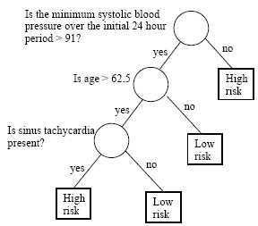

A heuristic decision tree used by the San Diego Medical Center for assessing heart attack patients, one of the [inspirations](https://rafalab.dfci.harvard.edu/pages/649/section-11.pdf) behind CART.

**Approach.**

- *Partition representation*. Observe a correspondence between the $L$ leaves of a tree diagram and size $L$ partitions of the input space $\mathcal{X} = R_{1} \cup R_{2} \cup \dots \cup R_{L}$.
- *Prediction rule*. For a test point $x^* \in R_{l}$, predict using the training samples in $R_{l}$: average $y_{i}$ for regression or majority class for classification.
- *Tree construction*. Grow the tree recursively using a greedy algorithm that optimizes locally for good prediction performance. Prune the tree using a validation set to ensure generalization ability.

## Trees $\iff$ Partitions

1. For now, let’s consider $x = \left(x_{1}, \dots, x_{J}\right)$ with only continuous features. Each node in a decision tree tests whether a feature $x_{j} \geq s$ or $x_{j} < s$ for some threshold $s$. We proceed down the right branch if and only if $x_j \geq s$.
2. A leaf node is a node without any descendants. Following the path from the root to a leaf, we impose a series of constraints on $x$ corresponding to axis-aligned rectangles.

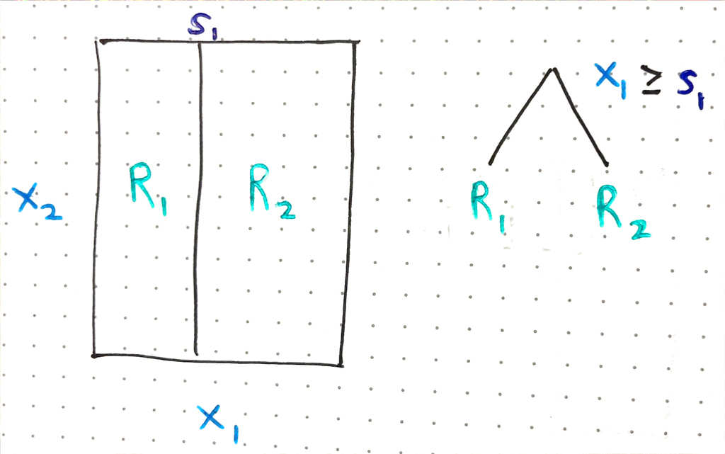

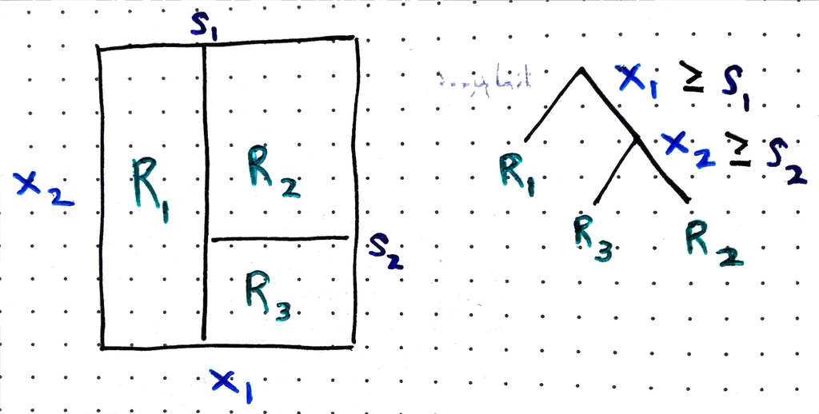

3. Since each $x$ follows exactly one root-to-leaf path, the $L$ leaves define $L$ nonoverlapping regions $\left(R_{l}\right)_{l = 1}^{L}$ that cover the entire input space: $\mathcal{X} = R_{1} \cup R_{2} \cup \dots \cup R_{L}$.

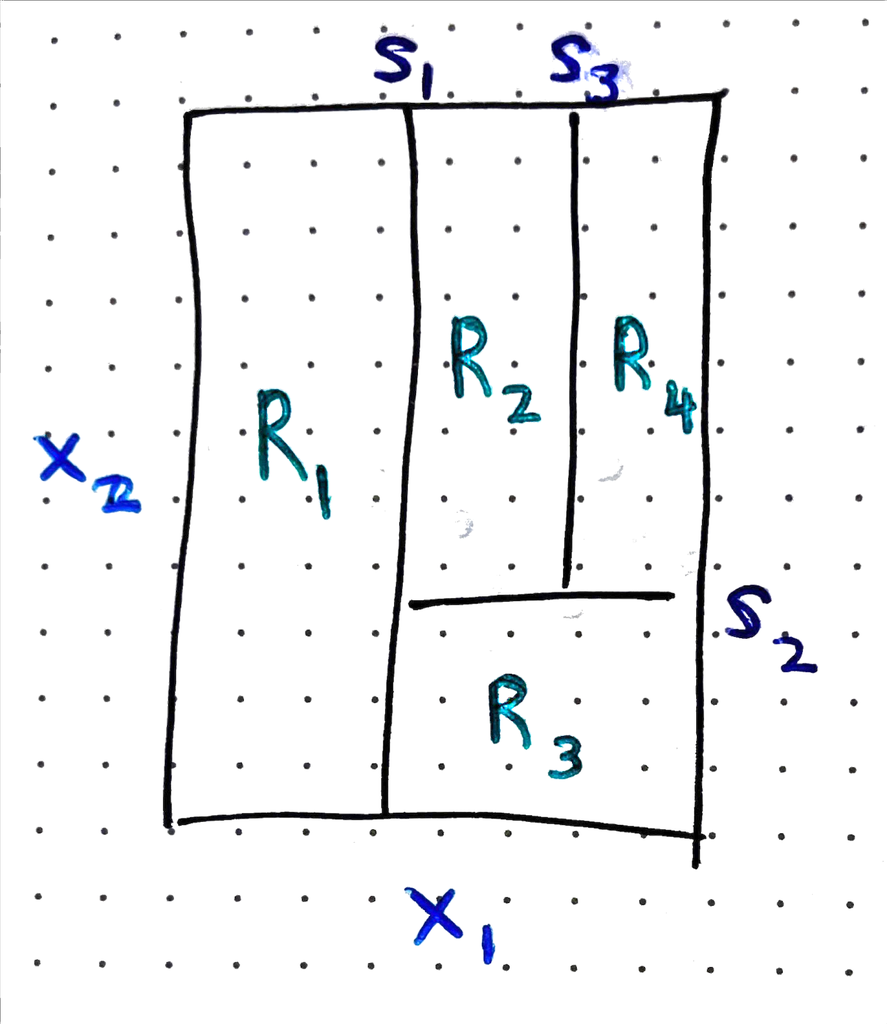

   *Exercise: What tree does this partition correspond to? Make sure to annotate the regions $R_{l}$ and split rules.*

## Growing Algorithm

1. **1D case**. How should we learn the partition from data $\{\left({x_i, y_i}\right)\}_{i = 1}^{N}$? First suppose we have only one feature and are only allowed one split. The resulting partition has only two elements $R^{\text{left}}$ and $R^{\text{right}}$, divided at a threshold $s$. We choose the $s$ that minimizes
   $$\begin{align*}
   \sum_{i: x_i \in R^{\text{left}}(s)} (y_i - \bar{y}_{R^{\text{left}}})^2 + \sum_{i: x_i \in R^{\text{right}}(s)} (y_i - \bar{y}_{R^{\text{right}}})^2
   \end{align*}$$

   where $\bar{y}_{R} = \frac{1}{|R|}\sum_{i: x_i \in R} y_i$ is the mean training response in region $R_{l}$.

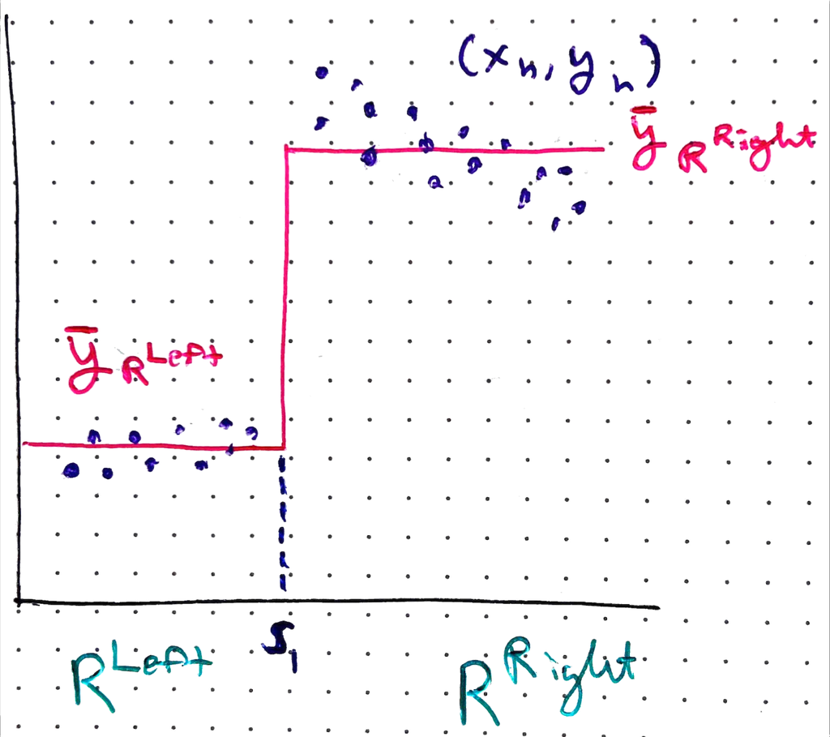

   *Exercise: The formula above has squared error terms like $\left(y_i - \bar{y}_{R^{\text{left}}}\right)^2$. How would you modify the figure to represent these quantities?*
2. **Inductive step**. Suppose we have already made $L$ splits, so we have $L + 1$ disjoint intervals $R_{1}, \dots, R_{L + 1}$ with current total residual sum of squares (RSS):
   $$\sum_{l=1}^{L +1} \sum_{i: x_i \in R_l} (y_i - \bar{y}_{R_l})^2$$
   To make the next split, consider the RSS reduction from splitting region $l$ at threshold $s$
   $$\Delta(l, s) = \sum_{i: x_i \in R_l} (y_i - \bar{y}_{R_l})^2 - \left[\sum_{i: x_i \in R_l^\text{left}(s)} (y_i - \bar{y}_{R_l^\text{left}})^2 + \sum_{i: x_i \in R_l^\text{right}(s)} (y_i - \bar{y}_{R_l^\text{right}})^2\right]
   \tag{1}$$
   Here, $R_l^\text{left}(s)$ and $R_l^\text{right}(s)$ denotes the left and right intervals made when splitting $R_l$ at $s$. We can test all regions $l \in \{1, \dots, L + 1\}$ and a fine grid of $s$ within each $R_{l}$. The best split is:
   $$\left(l^*, s^*\right) := \arg \max_{l, s} \Delta\left(l, s\right)$$

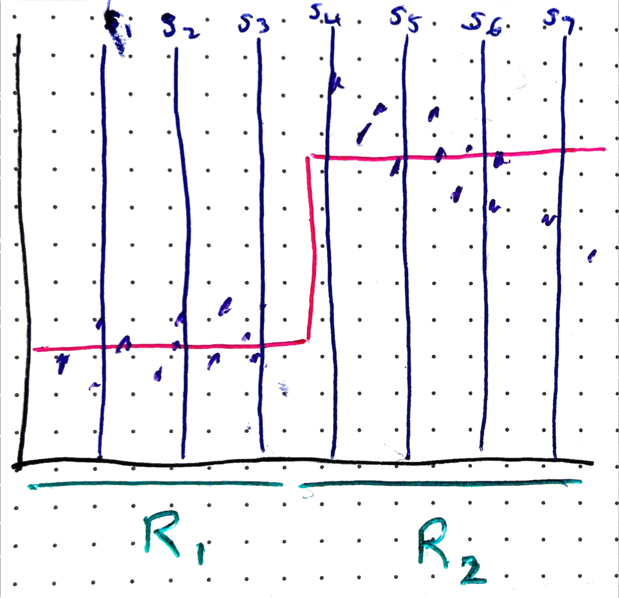

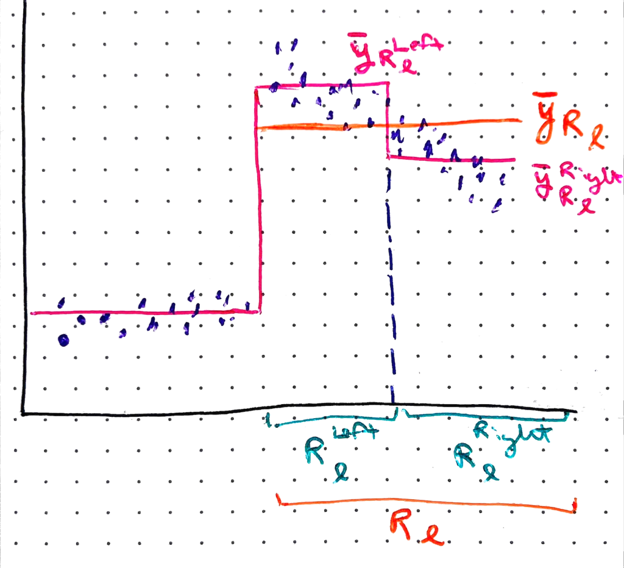

3. We stop growing the tree when we’ve reached a stopping criterion; e.g., when the best RSS improvement is too small or the leaves have too few samples to split further.
4. A similar approach works in higher dimensions – we just need to also optimize over which feature to split on in each inductive step.

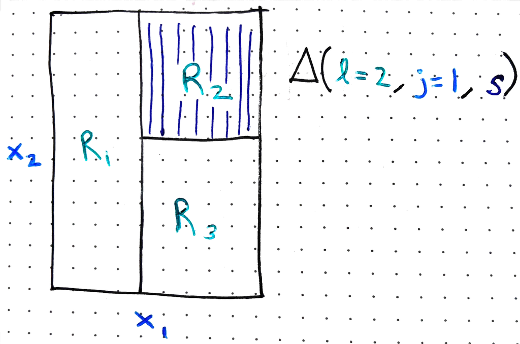

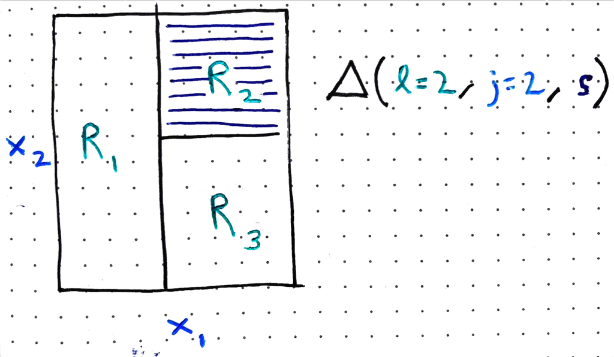

   Specifically, consider splitting leaf $l$ along feature $j$ at threshold $s$. The associated RSS reduction is:
   $$\Delta(l, j, s) = \sum_{i: x_i \in R_l} (y_i - \bar{y}_{R_l})^2 - \left[\sum_{i: x_i \in R_l^{\text{left}}(j,s)} (y_i - \bar{y}_{R_l^{\text{left}}})^2 + \sum_{i: x_i \in R_l^{\text{right}}(j,s)} (y_i - \bar{y}_{R_l^{\text{right}}})^2\right]
   \tag{2}$$
   where $R_l^{\text{left}}(j,s) = \{x \in R_l : x_j \leq s\}$ and $R_l^{\text{right}}(j,s) = \{x \in R_l : x_j > s\}$. We search over all candidate regions $l$, features $j$, and thresholds $s$ to find:
   $$(l^*, j^*, s^*) := \arg\max_{l, j, s} \Delta(l, j, s)$$

   *Exercise: Compare and contrast the formulas in Equation 1 and Equation 2 .*

## Classification

1. So far we’ve focused on regression. For classification, we still split recursively but can’t use $\Delta\left(l, j, s\right)$ as our objective.
2. Our first thought might be to use classification error rate instead of RSS. This is not a good idea, because we might want to split a region $R_{l}$ to improve “node purity,” even if it doesn’t improve the overall training error rate. For example, the split below is still worth making, even though the overall error rate is 40% in both cases. This is because the error rate in $R_3$ is now $\approx 27\%$ and is likely to generalize well.

   ```
   R_init (100 points): [●●●●●●●●●●●●●●●●●●●●●●●●●●●●●● ○○○○○○○○○○○○○○○○○○○○] 60:40 ratio

   After:
   R_2 (70 pts): [●●●●●●●●●●●●●●●●●●● ○○○○○○○○○○○○○○○○] 38:32
   R_3 (30 pts): [●●●●●●●●●●● ○○○○] 22:8
   ```

3. To measure node purity, we can use either the Gini Index or the Entropy. If $y$ belongs to one of $K$ classes and if $\hat{p}_{lk}$ denotes the proportion of class $k$ samples in region $R_{l}$, these are defined as,

   $$\begin{align*}
   \text{Gini}\left(R_{l}\right) &= \sum_{k= 1}^{K} \hat{p}_{lk}\left(1 - \hat{p}_{lk}\right)\\
   \text{Entropy}\left(R_{l}\right) &= -\sum_{k= 1}^{K} \hat{p}_{lk}\log\left(\hat{p}_{lk}\right)
   \end{align*}$$
4. Geometrically, these two functions have similar forms. The corners of the simplex below correspond to cases where most samples come from one of the $K = 3$ classes. A good classification tree will have learned regions $R_{l}$ whose class distributions are close to one of the $K$ corners of the simplex (similarly to how a good regression tree learns regions $R_{l}$ with low RSS).

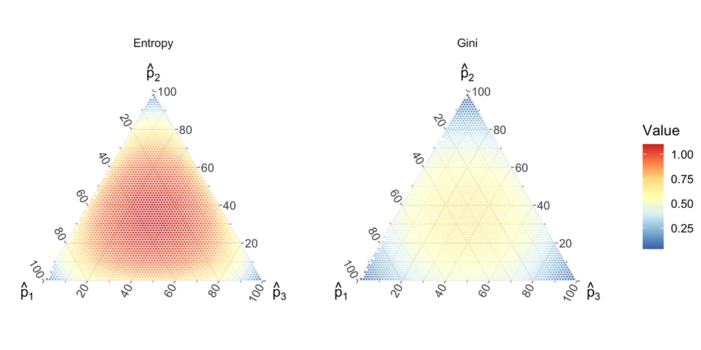

   *Exercise: What is the analogous figure when there are $K = 2$ classes?*
5. Given this new objective, we can define the tree growing induction as before:
   $$\Delta(l, j, s) = F\left(R_l\right) - \left[F\left(R_{l}^{\text{left}}(j, s)\right) + F\left(R_{l}^{\text{right}}(j, s)\right) \right]$$
   where $F$ denotes either the Gini index or Entropy. As before, we search over candidate leaves, directions, and thresholds to select the best possible split,
   $$(l^*, j^*, s^*) := \arg\max_{l, j, s} \Delta(l, j, s)$$

## Categorical Predictors

1. So far we’ve only considered continuous features $x \in \reals^{J}$. For categorical feature $x_j$ with $Q$ levels, we split by choosing a subset $A \subset \{1, \dots, Q\}$ and splitting on whether $x_{j} \in A$.

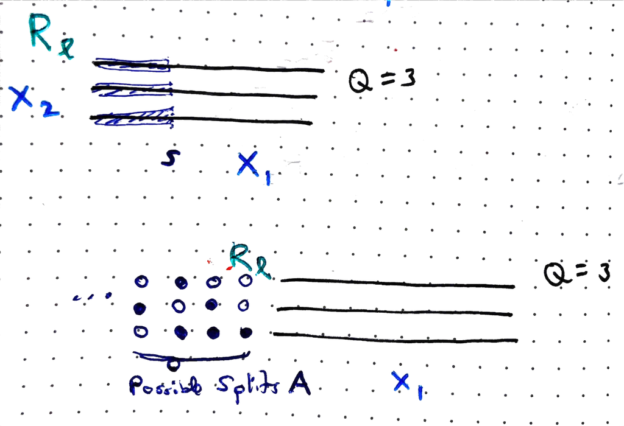

2. The RSS reduction for a categorical split becomes,

   $$\Delta(l, j, A) = \sum_{i: x_i \in R_l} (y_i - \bar{y}_{R_l})^2 - \left[\sum_{i: x_i \in R_l, \, x_{ij} \in A} (y_i - \bar{y}_{A})^2 + \sum_{i: x_i \in R_l, \, x_{ij} \in A^C} (y_i - \bar{y}_{A^C})^2\right]$$
   where $R_l^{A}(j) = \{x \in R_l : x_j \in A\}$ and similarly for $A^{C}$. We search over all candidate $l, j$, and subsets $A$ to find a choice that optimizes the RSS.
3. $^{\dagger}$ When $Q$ is large, there are $2^{Q - 1}$ possible subsets of $A$. For regression, we can reduce this to just $Q - 1$ splits.
   - For each level $q \in \{1, \ldots, Q\}$, compute the average $y_i$ among training points in $R_l$ with that level:
     $$\bar{y}_{q} = \frac{1}{|\{i : x_i \in R_l, \, x_{ij} = q\}|} \sum_{i : x_i \in R_l, \, x_{ij} = q} y_{i}$$
   - Sort the levels by these averages: $\bar{y}_{q_1} \leq \bar{y}_{q_2} \leq \cdots \leq \bar{y}_{q_Q}$
   - Only consider splits that respect this ordering: $A = \{q_1, \ldots, q_s\}$ for $s = 1, \ldots, Q-1$

   Intuitively, levels with similar average responses are grouped together in candidate splits.

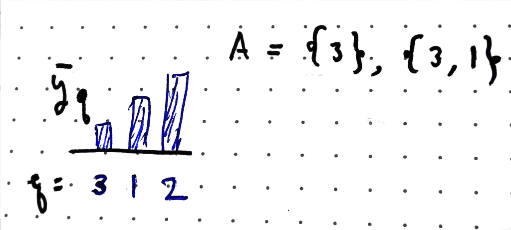

   *Exercise: In the figure above, why don’t we consider $A = \{1\}$ as a candidate split?*
4. Similar ordering strategies are possible for classification trees, but they are beyond the scope of this class.

## Cost Complexity Pruning

1. The tree growing algorithm may overfit, producing large trees with poor test performance and interpretability. The diagram below illustrates this with a one-dimensional dataset. Each step adds a split, shown as branching in the tree diagram (top) and finer partitions in the function plot (bottom, pink line). The last two splits add little value since the function is relatively flat in that region.

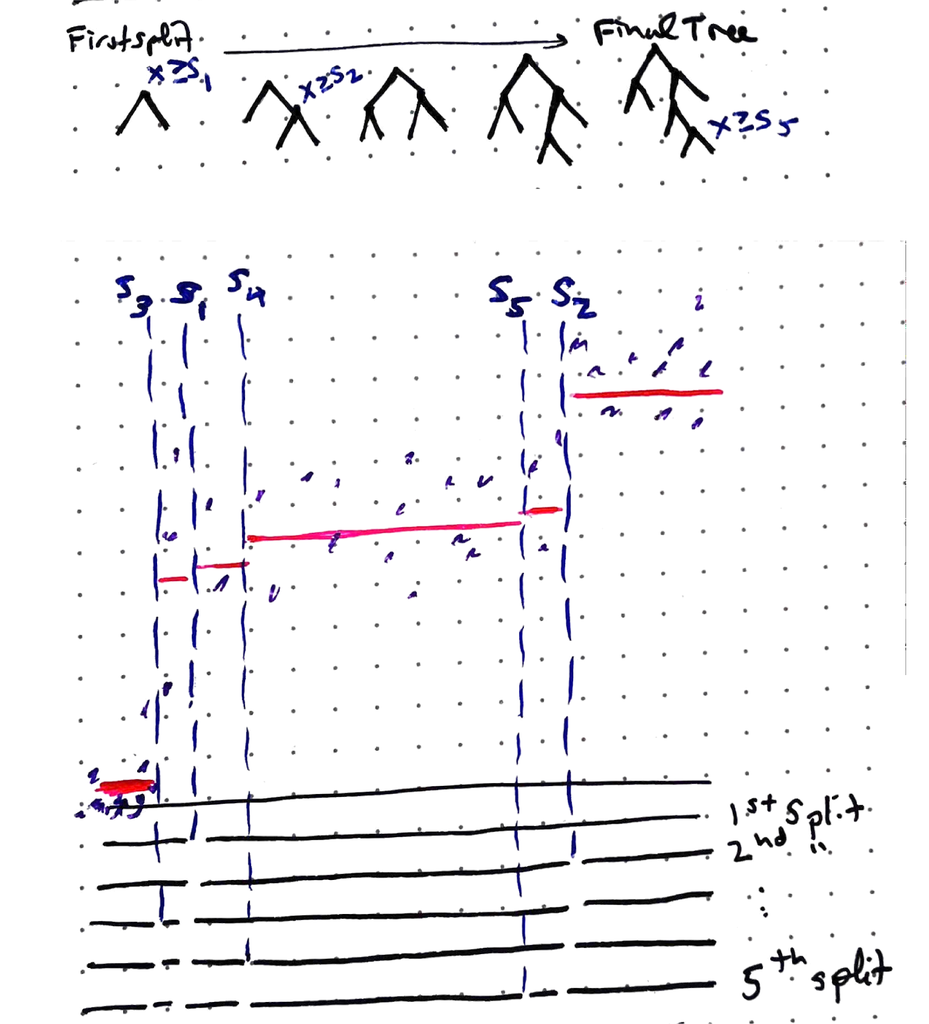

2. We could consider requiring larger improvements in $\Delta\left(l, j, s\right)$ before making a split. However, this is not a good idea – splits that don’t seem promising at first might enable valuable splits later, especially when features interact. For example, the initial split for $x_{1}$ below only gives a modest $\Delta$, since there is a mix of high and low $y$ values. After the split on $x_{2}$, though, the prediction is nearly perfect. A conservative rule that rejects the first split would miss this signal entirely.

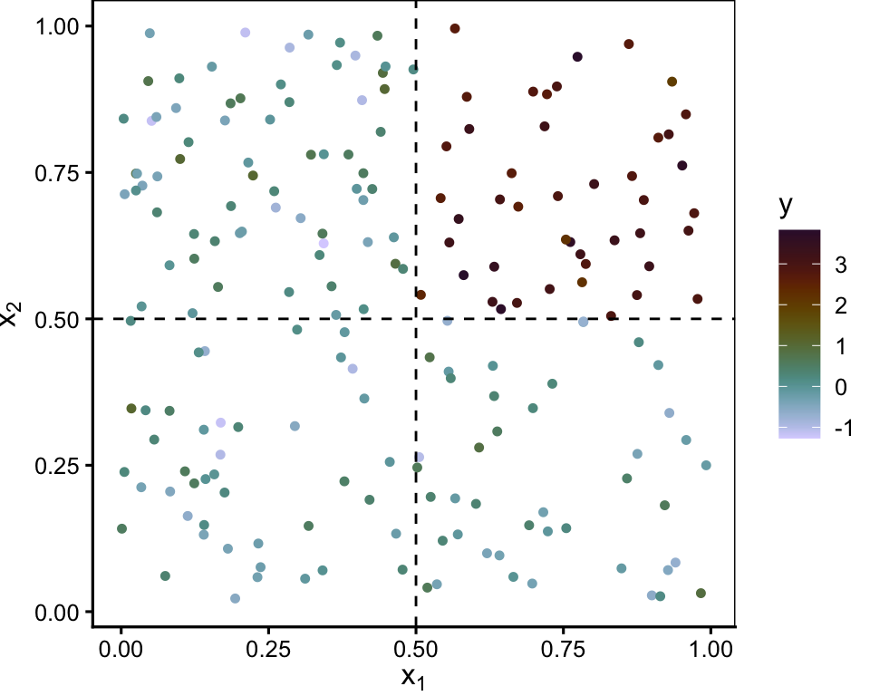

   *Exercise: Recall the definition of a feature interaction given at the start of these notes. How does this figure give an example of such an interaction?*
3. Let $T_0$ be the full tree. For penalty $\alpha \geq 0$, we find a subtree $T \subset T_0$ (formed by collapsing internal nodes) that minimizes:
   $$\mathcal{L}_{\alpha} = \sum_{l=1}^{|T|} \sum_{i: x_i \in R_l} (y_i - \bar{y}_{R_l})^2 + \alpha |T|$$
   where $|T|$ is the number of leaves in $T$. The first term is the training error, while $\alpha \left|T\right|$ penalizes tree complexity. When $\alpha = 0$, we keep the original tree. When $\alpha$ increases, the optimal subtree gets smaller. We tune $\alpha$ with cross-validation.

   *Exercise: The figure above shows the tree $T_0$ from the original growing process and a version formed by collapsing at the internal node $t$.*
   - *Which of the two trees has larger training error $\sum_{l=1}^{|T|} \sum_{i: x_i \in R_l} (y_i - \bar{y}_{R_l})^2$? If it cannot be determined, explain why.*
   - *Which has larger $\left| T\right|$? If it cannot be determined, explain why.*
4. $^{\dagger}$ For an internal node $t$ in the tree, define,
   - $T_t$: The subtree rooted at $t$ (node $t$ and all its descendants).
   - $\text{RSS}\left(t\right)$: The RSS if we collapse $T_t$ into a single leaf $t$,
     $$\begin{align*}
     \text{RSS}\left(t\right) &= \sum_{i \in T_{t}} \left(y_i - \bar{y}_{T_t}\right)^{2}
     \end{align*}$$
     where $\bar{y}_{T_{t}}$ is the average response among training samples in the subtree $T_{t}$. Below, this sums over all samples in the orange segment, measuring squared distances from each $y_i$ to $\bar{y}_{T_{t}}$.
   - $\text{RSS}\left(T_t\right)$: The RSS when summing over leaves in the subtree $T_t$,
     $$\begin{align*}
     \text{RSS}\left(T_t\right) &= \sum_{l \in T_t}\sum_{i \in R_{l}} \left(y_i - \bar{y}_{R_{l}}\right)^{2}.
     \end{align*}$$
     Below, the outer sum loops over the three pink segments; the inner sum loops over points within each segment, measuring squared distances from each $y_i$ to its$\bar{y}_{R_{l}}$.

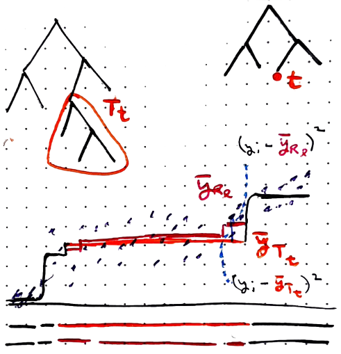

   *Exercise: For any given $t$, is $RSS\left(t\right) \geq RSS\left(T_t\right)$, $RSS\left(t\right) < RSS\left(T_t\right)$, or “it depends on $t$”?*
5. $^{\dagger}$ Keeping $T_t$ vs. collapsing it improves the RSS by $\text{RSS}(t) - \text{RSS}(T_t)$ at a cost of $|T_t| - 1$ extra leaves. The cost-benefit ratio is:
   $$\alpha_t := \frac{\text{RSS}(t) - \text{RSS}(T_t)}{|T_t| - 1}$$
   This is the RSS reduction per additional leaf. Nodes with small $\alpha_t$ provide little benefit relative to their complexity.

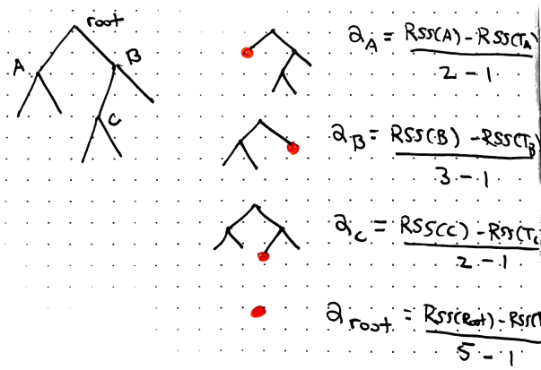

6. $^{\dagger}$ This suggests the weakest-link pruning algorithm.
   - Compute $\alpha_t$ for each internal node $t$ in the current tree
   - Collapse the subtree $T_t$ with the smallest $\alpha_t$ (the “weakest link”)
   - Repeat until only the root remains

   This yields a sequence of subtrees $T_0 \supset T_1 \supset \cdots \supset T_M$. The $m$-th pruning step removes a node with cost-benefit ratio $\alpha_{(m)}$, giving thresholds $0 = \alpha_{(0)} < \alpha_{(1)} < \cdots < \alpha_{(M)}$. For any penalty $\alpha \in [\alpha_{(m)}, \alpha_{(m+1)})$, the optimal subtree minimizing $\mathcal{L}_{\alpha}(T)$ is $T_m$.
7. The link pruning algorithm applies to higher dimensions. For example, the figure below shows how collapsing a subtree simplifies a partition in two-dimensions.

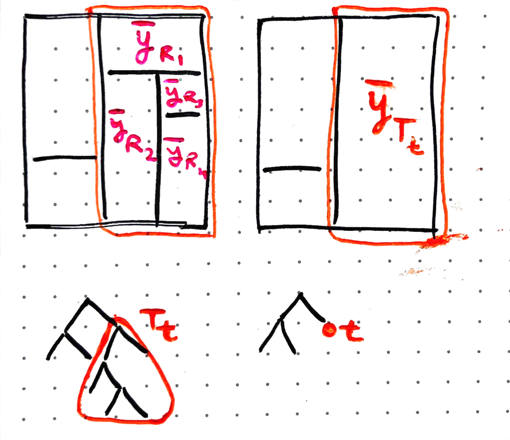

## Code Example

1. We’ll use `rpart` to fit regression trees to the 2D dataset below, which has strong interactions between $x_1$ and $x_2$ and isn’t a simple piecewise constant surface.

   ```r
   library(rpart)
   library(rpart.plot)

   sim_data <- tibble(
     x1 = runif(500),
     x2 = runif(500),
     y = 10 * sin(pi * x1 * x2) + 20 * (x2 - 0.5)^2 + rnorm(500)
   )
   ```

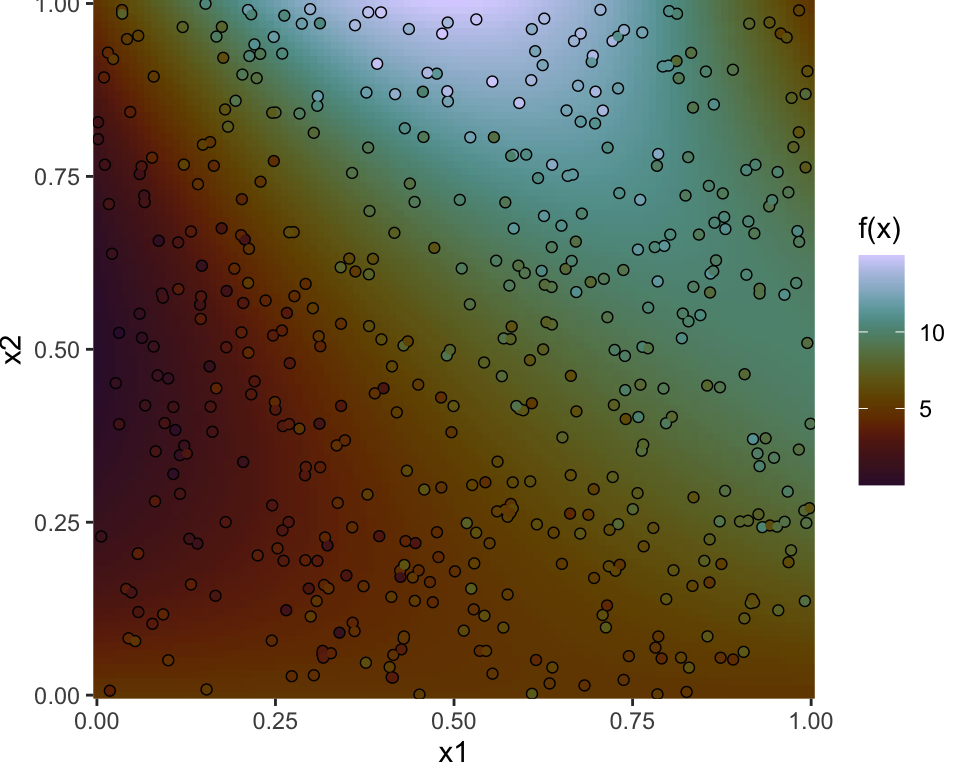

2. We fit a regression tree with default $\alpha$. Each leaf region $R_{l}$ predicts $\bar{y}_{R_{l}}$.

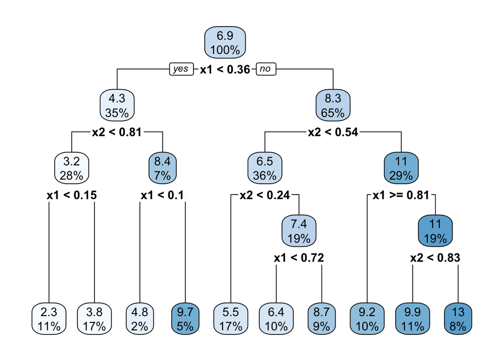

   ```r
   fit <- rpart(y ~ x1 + x2, data = sim_data)
   rpart.plot(fit)
   ```

   This is the associated partition of the feature space $\mathcal{X} = \left[0, 1\right]^{2}$. Each leaf in the tree is one axis-aligned rectangle.

   ```r
   grid$pred <- predict(fit, newdata = grid)
   ```

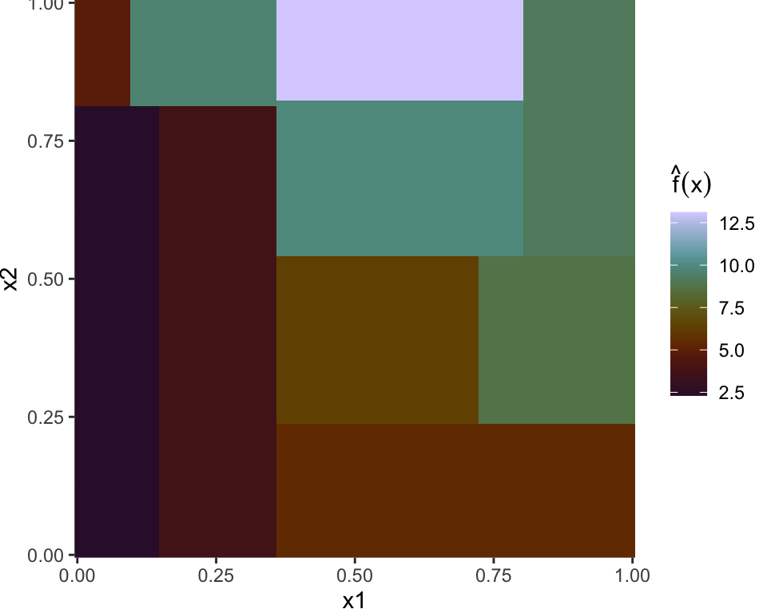

3. Let’s study the influence of $\alpha$. The `cp` hyperparameter in rpart is $\alpha$ normalized by the root node’s RSS; the normalization makes `cp` comparable across datasets. We can see that when cp is small, we are left with a large tree (fine partition), while when cp is large, we have a simpler tree (coarse partition).

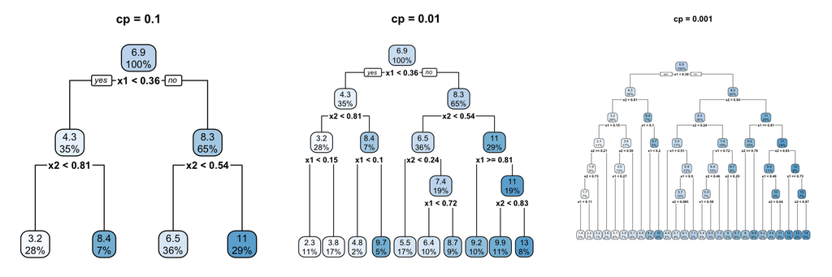

   ```r
   par(mfrow = c(1, 3), mar = c(2, 2, 3, 1))
   for (cp_val in c(0.1, 0.01, 0.001)) {
    rpart.plot(
    rpart(y ~ x1 + x2, data = sim_data, cp = cp_val),
    main = paste("cp =", cp_val)
    )
   }
   ```

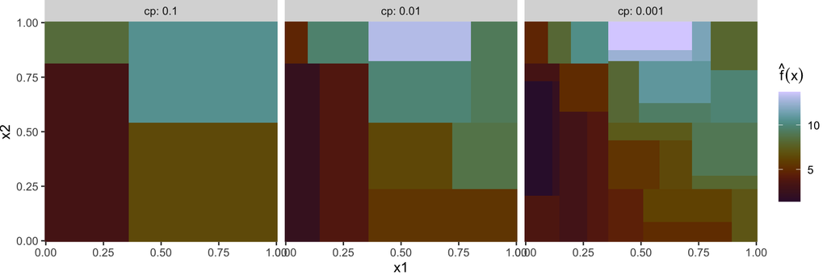

4. `fit$frame` and `fit$where` help inspect individual nodes. `fit$frame` gives node statistics: sample counts, average values $\bar{y}_{R_{l}}$, and pruning thresholds $\alpha_{m}$.

   ```r
   fit$frame
   ```

   ```
         var   n  wt        dev      yval  complexity ncompete nsurrogate
   1      x1 500 500 5748.81339  6.907771 0.320308139        1          1
   2      x2 176 176 1357.90713  4.303991 0.133486128        1          0
   4      x1 139 139  311.38191  3.226672 0.013370287        1          1
   8  <leaf>  55  55   92.62064  2.307683 0.004669844        0          0
   9  <leaf>  84  84  141.89799  3.828391 0.006085289        0          0
   5      x1  37  37  279.13837  8.351216 0.030283514        1          0
   10 <leaf>  10  10   21.29115  4.786924 0.010000000        0          0
   11 <leaf>  27  27   83.75296  9.671324 0.004558962        0          0
   3      x2 324 324 2549.51454  8.322170 0.224585945        1          1
   6      x2 178 178  573.88705  6.514270 0.029379612        1          1
   12 <leaf>  83  83  131.95147  5.472133 0.006684417        0          0
   13     x1  95  95  273.03767  7.424769 0.022796693        1          1
   26 <leaf>  52  52   87.78750  6.356709 0.004235767        0          0
   27 <leaf>  43  43   54.19624  8.716377 0.010000000        0          0
   7      x1 146 146  684.52480 10.526321 0.033186487        1          1
   14 <leaf>  50  50  100.09881  9.180712 0.006617028        0          0
   15     x2  96  96  446.74007 11.227159 0.033186487        1          1
   30 <leaf>  56  56  135.34135  9.880095 0.006896626        0          0
   31 <leaf>  40  40   67.51881 13.113050 0.003096152        0          0
   ```

   `fit$where` tells which leaf each point belongs to; i.e., it groups similar points from the tree’s point of view. The vector names are the data.frame row numbers from the frame object above.

   ```r
   table(fit$where)
   ```

   ```
    4  5  7  8 11 13 14 16 18 19
   55 84 10 27 83 52 43 50 56 40
   ```